# COVID-19 Research Project

Lauren Thomas

August 11, 2020

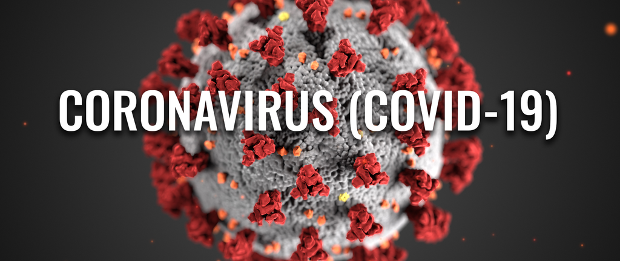

COVID-19

## Introduction

This project is for Biology 390: Reproducible Research at Ferris State University. I worked with a large dataset to create and share a reproducible research report online on my own website. The topic of COVID-19 (Corona Virus) pandemic was chosen because it is of great interest to the world at this point in time. After researching many datasets, I created a hypothesis of my own to explore. This project is under version control using git/Github and is written as an R markdown (Rmd) file.

## Hypothesis

COVID-19 reached ‘pandemic’ status quite some time ago. A pandemic is where a disease is prevelant over the entire world. It is everywhere. And living in this pandemic, it is hard to remember life before or when all this even started; it all happened so fast. I remember hearing something about China and a bat a while ago. But which two countries were (actually) the first to see this virus? And how would they compare in regards to number of cases versus satefty measurements their nation took? It’s easy to assume the first country to see COVID-19 would be the first to get it under control. Here is my hypothesis; *faster safety measure implementation leads to a faster decrease in cases.*

## Data

For this project I used two different data sets that were available online for free. This is the information I used:  
**1.** Systematic dataset of COVID-19 policy, from Oxford University.  
URL: *[www.bsg.ox.ac.uk/covidtracker](https://www.bsg.ox.ac.uk/research/research-projects/coronavirus-government-response-tracker)*  
**2.** Data on COVID-19 confirmed cases, deaths, and tests. All countries. Updated daily by ‘Our World in Data’.  
URL: *ourworldindata.org/coronavirus*  
**Image.** *[www.pisab.org] (https://www.pisab.org/wp-content/uploads/2020/05/CoronaVirusHeader-Final-3.jpg)*

## Analyses

When it came to the analytics, I decided to do 4 analyses to explore my hypothesis. I decided on investigating two specific satefy measures; work from home regulations and stay at home orders. I was interested to see if these enforcements graphically made a difference in the number of confirmed cases (the affect on death rates was not investigated). Using these data sources in combination, I first began with searching for which two countries were the first to see the virus.

### The first cases of COVID-19 ever to be documented

First COVID-19 Case

| Total_Cases | Date | Country |
| --- | --- | --- |
| 1 | 2020-01-13 | Thailand |
| 1 | 2020-01-15 | Japan |

| ID | Name | Description | Measurement | Coding |
| --- | --- | --- | --- | --- |
| C2 | C2_Workplace closing | Record closings of workplaces | Ordinal Scale | 0 - no measures |
|  |  |  |  | 1 - recommend closing (or recommend work from home) |
|  |  |  |  | 2 - require closing (or work from home) for some sectors or categories of workers. |
|  |  |  |  | 3 - require closing (or work from home) for all-but-essential workplaces (eg grocery stores, doctors) |
|  |  |  |  | blank - no data |
| C6 | C6_Stay at home rerquirements | Record orders to "shelter-in-place" and otherwise confine to the home | Ordinal Scale | 0 - no measures |
|  |  |  |  | 1 - recommend not leaving house |
|  |  |  |  | 2 - require not leaving house with exceptions for daily exercise, grocery shopping, and 'essential trips' |
|  |  |  |  | 3 - require not leaving house with minimal exceptions (eg allowed to leave house once a week, or only one person can leave aat a time, etc) |
|  |  |  |  | blank - no data |

### The implementation of a workplace restriction in Thailand

First Workplace Restriction

| Ordinal Scale | date | Country |
| --- | --- | --- |
| 0 | 2020-03-16 | Thailand |
| 2 | 2020-03-17 | Thailand |

### The implementation of a workplace restriction in Japan

First Workplace Restriction

| Ordinal Scale | date | Country |
| --- | --- | --- |
| 0 | 2020-02-24 | Japan |
| 1 | 2020-02-25 | Japan |

As you can see, Japan was first to restrict the workforce. In fact, they were 21 days before Thailand- almost a month. In addition to this, the level of strictness differs. Thailand was only one level ‘stricter’ than Japan. Neither of these countries chose the strictest measures.  
Now let us look at number of official confirmed cases of COVID-19 in both countries *before* workforce changes. Below, you can see the line graph displaying this information. The time-line of the graph starts with each countries first case up till the time of the workforce restriction.

### COVID-19 before workforce restriction

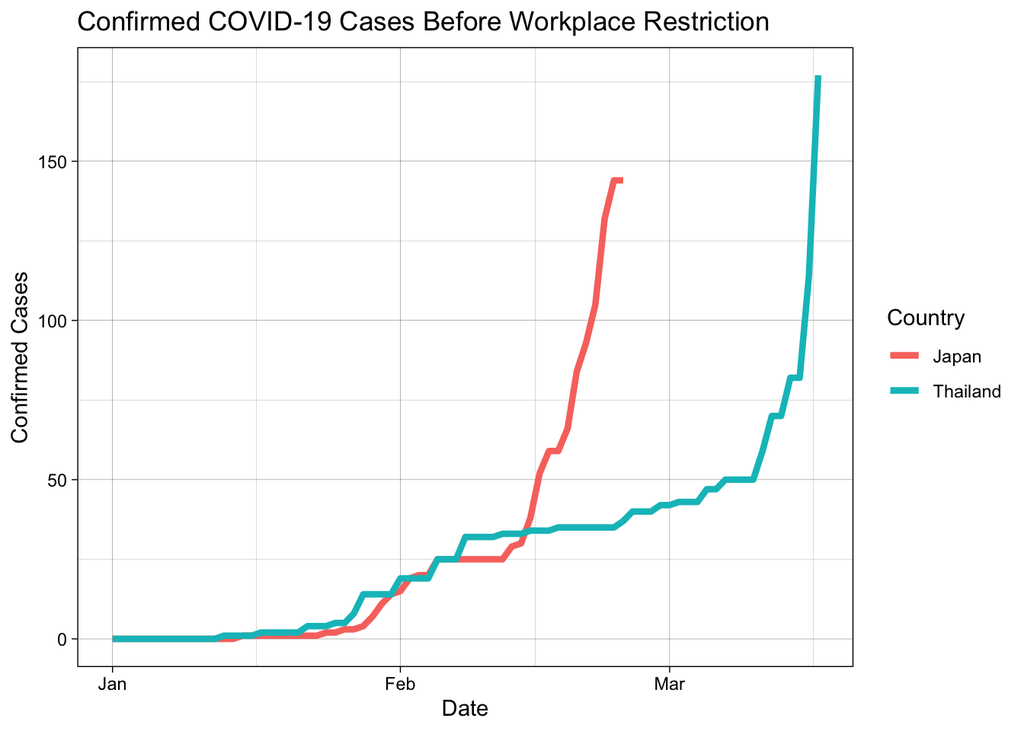

As you can see, Thailand does indeed start before Japan and rises for a small amount of time at a greater rate than Japan. However, mid-Feb shows a huge increase of confirmation rate in Japan. According to [Worldometers.info](https://www.worldometers.info/world-population/thailand-population/#:~:text=The%20current%20population%20of%20Thailand,of%20the%20total%20world%20population.), Thailand’s 2020 population is about 69 million. In comparison, Japan’s population is estimated to be around 126 million.  
Below is the graph showing confirmed cases *after* the work-place restrictions.

### COVID-19 after workforce restriction

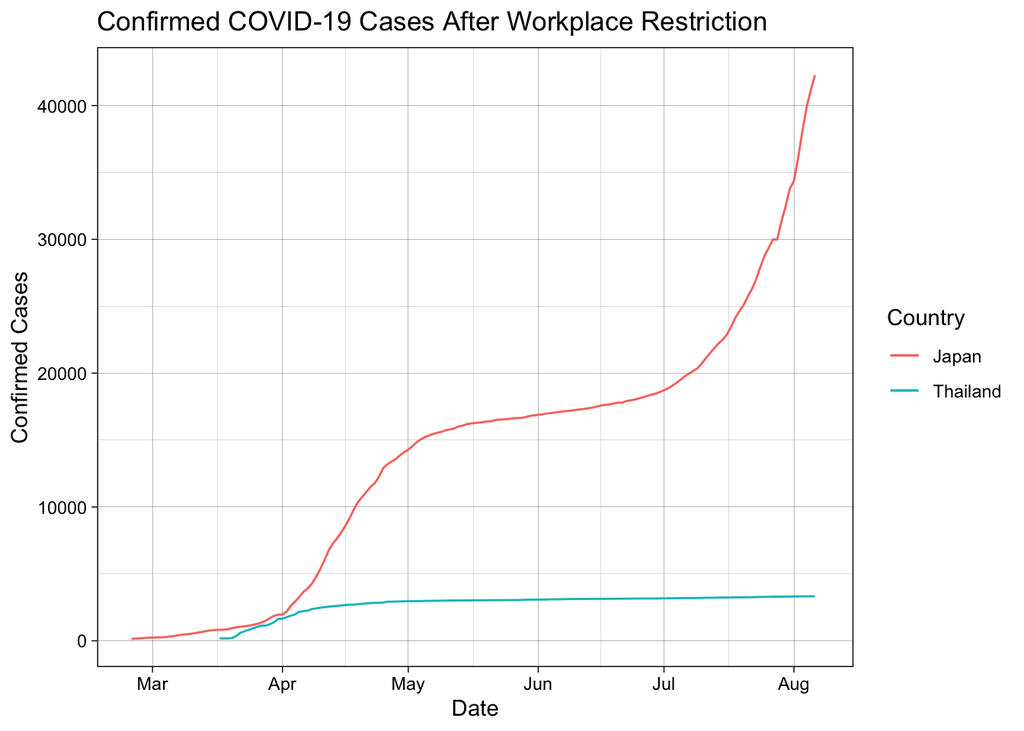

The first thing you might notice is that the graph seems much more smoother. This indicates less of a presence of rapid increases in cases. The most striking difference is that Japan continues to climb, leveling off a bit between May and July, while Thailand levels off shortly after the changes made and continued to stay that way. Remember, Thailand was 21 days later than Japan but was one level higher on the ordinal scale. *(Refer to Figure 1 at beginning of report to see what each level represents)*  
This information suggests that the addition of work-place restrictions was beneficial in both countries; however, more intensely in Thailand.  
The second regulation I investigated was stay-at-home orders in both countries. Let’s see if there are similar trends. Just like previously, I started with pinpointing the first date these orders were in effect in Thailand and Japan. Who was first this time?

### The implementation of a stay at home order in Thailand

First Stay at Home Restriction

| Ordinal Scale | date | Country |
| --- | --- | --- |
| 0 | 2020-03-20 | Thailand |
| 1 | 2020-03-21 | Thailand |

### The implementation of a stay at home order in Japan

First Stay at Home Restriction

| Ordinal Scale | date | Country |
| --- | --- | --- |
| 0 | 2020-04-06 | Japan |
| 1 | 2020-04-07 | Japan |

This time Thailand was first; 17 days ahead of Japan. (Opposite of what was seen previously). Also, booth countries had the same level in ordinal scale.  
Now how did this affect COVID cases? See the line graphs below to find out. The first graph, like before shows cases *before* any implementation of restrictions.

### COVID-19 cases before stay at home order

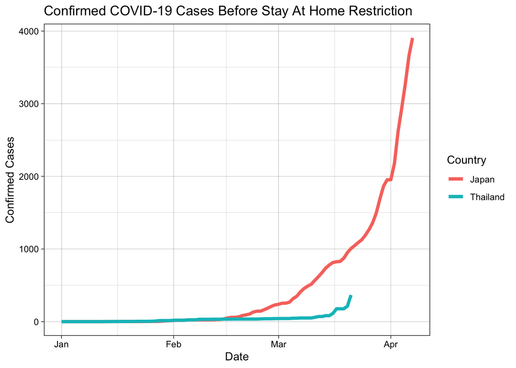

Visually, this graph is similar to the previous ‘before’ graph. It just looks a little different because the timeline is a bit longer here- right before stay-at-home orders were made.

### COVID-19 cases after stay at home order

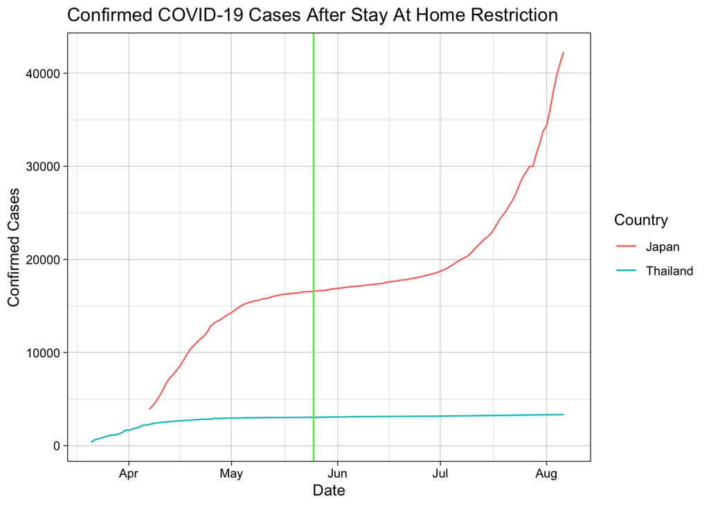

## Conclusions

So what does all of this information mean? In both sets of graphs the rate was lowered after satefty measures were taken. Each country decreased at different rates; Thailand’s cases dropped dramatically while Japan’s slowed down but cases still seemed to climb.This difference could be due to the discrepency in population (Japan, with almost twice the population as Thailand). This discrepancy becomes much larger in the second set of graphs where Japan lifts up on the lockdown. This analysis was not conclusive by any means and more analyses should be made before a definitive answer is reached. However, what I have found does suggest that faster safety measure implementation *and* the contonuation of said implementation does lead to a faster decrease in confirmed case rates.

### Viewing this project

The completed project files can be accessed online at file:///Users/laurenthomas/COVID-19/README.html. The repo for this reproducible project is also publicly available at https://github.com/thomal29/COVID-19